# Mice_Data_EDA_Dillon_Duff

## Part 1: PCA

### Data From: [Mice Protein Expression](https://archive.ics.uci.edu/dataset/342/mice+protein+expression)

Higuera,Clara, Gardiner,Katheleen, and Cios,Krzysztof. (2015). Mice Protein Expression. UCI Machine Learning Repository. https://doi.org/10.24432/C50S3Z.

Expression levels of 77 proteins measured in the cerebral cortex of 8 classes of control and Down syndrome mice exposed to context fear conditioning, a task used to assess associative learning.

```python
import pandas as pd

mice = pd.read_excel("Data_Cortex_Nuclear.xls").set_index('MouseID')
mice.head()
```

| MouseID | DYRK1A_N | ITSN1_N | BDNF_N | NR1_N | NR2A_N | pAKT_N | pBRAF_N | pCAMKII_N | pCREB_N | pELK_N | ... | pCFOS_N | SYP_N | H3AcK18_N | EGR1_N | H3MeK4_N | CaNA_N | Genotype | Treatment | Behavior | class |
| --- | --- | --- | --- | --- | --- | --- | --- | --- | --- | --- | --- | --- | --- | --- | --- | --- | --- | --- | --- | --- | --- |
| 309_1 | 0.503644 | 0.747193 | 0.430175 | 2.816329 | 5.990152 | 0.218830 | 0.177565 | 2.373744 | 0.232224 | 1.750936 | ... | 0.108336 | 0.427099 | 0.114783 | 0.131790 | 0.128186 | 1.675652 | Control | Memantine | C/S | c-CS-m |
| 309_2 | 0.514617 | 0.689064 | 0.411770 | 2.789514 | 5.685038 | 0.211636 | 0.172817 | 2.292150 | 0.226972 | 1.596377 | ... | 0.104315 | 0.441581 | 0.111974 | 0.135103 | 0.131119 | 1.743610 | Control | Memantine | C/S | c-CS-m |
| 309_3 | 0.509183 | 0.730247 | 0.418309 | 2.687201 | 5.622059 | 0.209011 | 0.175722 | 2.283337 | 0.230247 | 1.561316 | ... | 0.106219 | 0.435777 | 0.111883 | 0.133362 | 0.127431 | 1.926427 | Control | Memantine | C/S | c-CS-m |
| 309_4 | 0.442107 | 0.617076 | 0.358626 | 2.466947 | 4.979503 | 0.222886 | 0.176463 | 2.152301 | 0.207004 | 1.595086 | ... | 0.111262 | 0.391691 | 0.130405 | 0.147444 | 0.146901 | 1.700563 | Control | Memantine | C/S | c-CS-m |
| 309_5 | 0.434940 | 0.617430 | 0.358802 | 2.365785 | 4.718679 | 0.213106 | 0.173627 | 2.134014 | 0.192158 | 1.504230 | ... | 0.110694 | 0.434154 | 0.118481 | 0.140314 | 0.148380 | 1.839730 | Control | Memantine | C/S | c-CS-m |

5 rows × 81 columns

### Data Preprocessing

Filling all NA values with 0 and removing all non-target, categorical features, then ensuring all datatypes are numeric except for our target.

```python
import pandas as pd

mice = pd.read_excel("Data_Cortex_Nuclear.xls").set_index('MouseID')
mice = mice.fillna(0)

mice.head()

mice = mice.drop(columns=["Genotype", "Treatment", "Behavior"])

mice.dtypes.values
```

```
array([dtype('float64'), dtype('float64'), dtype('float64'),
       dtype('float64'), dtype('float64'), dtype('float64'),
       dtype('float64'), dtype('float64'), dtype('float64'),
       dtype('float64'), dtype('float64'), dtype('float64'),
       dtype('float64'), dtype('float64'), dtype('float64'),
       dtype('float64'), dtype('float64'), dtype('float64'),
       dtype('float64'), dtype('float64'), dtype('float64'),
       dtype('float64'), dtype('float64'), dtype('float64'),
       dtype('float64'), dtype('float64'), dtype('float64'),
       dtype('float64'), dtype('float64'), dtype('float64'),
       dtype('float64'), dtype('float64'), dtype('float64'),
       dtype('float64'), dtype('float64'), dtype('float64'),
       dtype('float64'), dtype('float64'), dtype('float64'),
       dtype('float64'), dtype('float64'), dtype('float64'),
       dtype('float64'), dtype('float64'), dtype('float64'),
       dtype('float64'), dtype('float64'), dtype('float64'),
       dtype('float64'), dtype('float64'), dtype('float64'),
       dtype('float64'), dtype('float64'), dtype('float64'),
       dtype('float64'), dtype('float64'), dtype('float64'),
       dtype('float64'), dtype('float64'), dtype('float64'),
       dtype('float64'), dtype('float64'), dtype('float64'),
       dtype('float64'), dtype('float64'), dtype('float64'),
       dtype('float64'), dtype('float64'), dtype('float64'),
       dtype('float64'), dtype('float64'), dtype('float64'),
       dtype('float64'), dtype('float64'), dtype('float64'),
       dtype('float64'), dtype('float64'), dtype('O')], dtype=object)
```

#### Normalizing data

```python
from sklearn.preprocessing import StandardScaler

X = mice.iloc[:, :-1]
y = mice.iloc[:, -1]

scaler = StandardScaler()
scaler.fit(X)

X = scaler.transform(X)
print("After scaling:")
print(f"Mean: {round(X.mean())}, Std Dev: {X.std()}")
```

```
After scaling:
Mean: 0, Std Dev: 1.0
```

### PCA Analysis

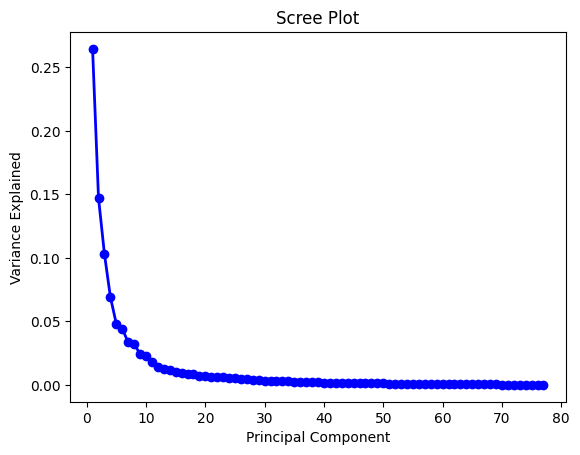

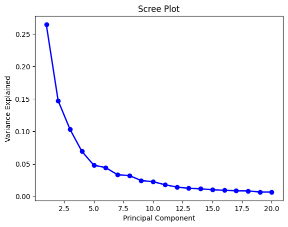

```python
from sklearn.decomposition import PCA
import matplotlib.pyplot as plt
import numpy as np

max_components = X.shape[1]
explained_vars = []

pca = PCA()
pca.fit(X)

PC_values = np.arange(pca.n_components_) + 1
plt.title('Scree Plot')
plt.xlabel('Principal Component')
plt.ylabel('Variance Explained')
plt.plot(PC_values, pca.explained_variance_ratio_, 'o-', linewidth=2, color='blue')
plt.show()

plt.title('Scree Plot')
plt.xlabel('Principal Component')
plt.ylabel('Variance Explained')
plt.plot(PC_values[:20], pca.explained_variance_ratio_[:20], 'o-', linewidth=2, color='blue')
plt.show()
```

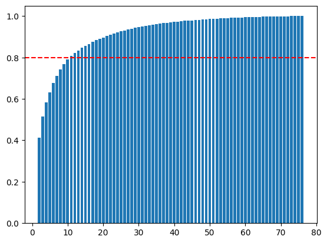

```python
max_components = X.shape[1]
explained_vars = []
components = range(2, max_components)

for n in components:
  pca = PCA(n_components=n)
  pca.fit(X)
  explained_vars.append(pca.explained_variance_ratio_.sum())

plt.bar(components, explained_vars)
plt.axhline(y=0.8, color='r', linestyle='--')

plt.plot()
plt.show()
```

```python
pca = PCA(n_components=10)
pca.fit(X)
print(pca.explained_variance_ratio_)
principal_components = pd.DataFrame(pca.fit_transform(X)).add_prefix("PC_")
print(principal_components.shape)
principal_components.head()
```

```
[0.26455587 0.14716558 0.10313688 0.06931726 0.04810865 0.04438954
 0.03341723 0.03211242 0.02445899 0.02266765]
(1080, 10)
```

|  | PC_0 | PC_1 | PC_2 | PC_3 | PC_4 | PC_5 | PC_6 | PC_7 | PC_8 | PC_9 |
| --- | --- | --- | --- | --- | --- | --- | --- | --- | --- | --- |
| 0 | -4.150955 | 4.895383 | -1.697359 | -1.914845 | -0.656578 | -1.751032 | 0.097405 | -1.640738 | 0.073194 | 0.670970 |
| 1 | -2.563561 | 4.804694 | -0.828003 | -1.477055 | -0.322639 | -1.350438 | -0.064896 | -1.560747 | 0.114154 | 0.649332 |
| 2 | -2.653338 | 5.035137 | -0.532225 | -1.225550 | -0.049044 | -1.335527 | -0.061384 | -1.691167 | 0.092926 | 0.822455 |
| 3 | -0.524966 | 3.552818 | -2.643805 | -0.672265 | -0.034253 | -1.771901 | -0.598430 | -1.592101 | 0.266566 | 0.981033 |
| 4 | 0.554189 | 3.672825 | -1.477561 | -0.398714 | 0.204644 | -1.538511 | -1.017883 | -1.396780 | 0.360445 | 0.880512 |

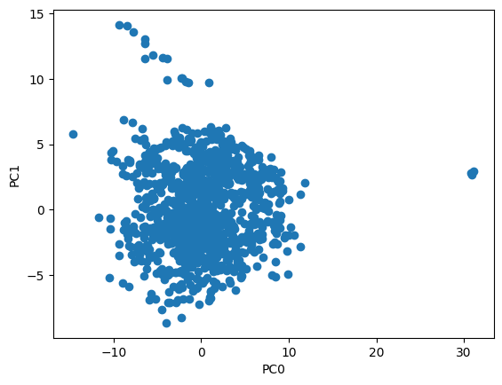

```python
plt.scatter(principal_components.iloc[:, 0], principal_components.iloc[:, 1])
plt.xlabel('PC0')
plt.ylabel('PC1')
plt.show()
```

#### There seem to be some outliers, with the data mostly grouped into one, maybe two clusters.

### Discuss

In this context, dimensionality reduction allows us to reduce the volume of features we are looking at in our dataset and it allows us to reduce the noise of certain chemicals or columns that have little effect.

With less dimensions, we are also more easily able to visualize the data and view possible clusters. With higher dimensionality, this may not be possible.

## Part 2 LDA

### Correlation heatmap

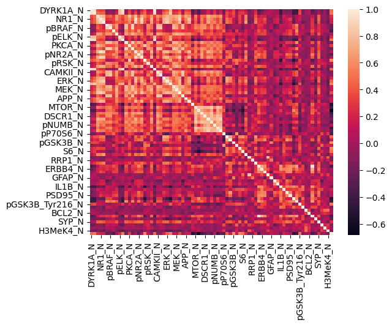

```python
import seaborn as sns

sns.heatmap(mice.corr())
pass
```

#### There seem to be some patterns here in the correlation matrix. It is possible to imagine clusters bassed on some of these correlations. There are too many features here to speak on specific correlations, though.

### LDA

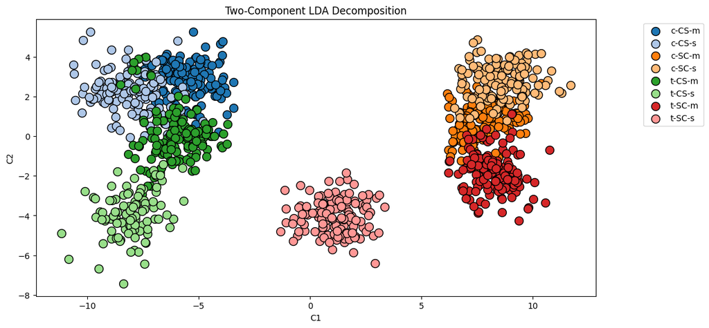

```python
from sklearn.discriminant_analysis import LinearDiscriminantAnalysis as LDA
import matplotlib as mpl
lda = LDA()
X_lda = lda.fit_transform(X, y)

colors = mpl.cm.get_cmap(name='tab20').colors
categories = pd.Categorical(pd.Series(y)).categories
ret = pd.DataFrame(
    {'C1': X_lda[:, 0], 'C2': X_lda[:, 1], 'Type': pd.Categorical(pd.Series(y))}
)

fig, ax = plt.subplots(1, figsize=(12, 6))

for col, cat in zip(colors, categories):
    (ret
         .query('Type == @cat')
         .plot.scatter(x='C1', y='C2', color=col, label=cat, ax=ax,
                       s=100, edgecolor='black', linewidth=1,
                       title='Two-Component LDA Decomposition')
         .legend(bbox_to_anchor=(1.2, 1))
    )
    pass
```

#### It appears that LDA was able to separate these 8 classes reasonably well, with some entirely separate than others. There is still a decent amount of overlap on the two sides, but for the most part the clusters are separated and the classes are distinguishable. This gives good evidence to support that these classes are linearly separable.

### Discussion

PCA and LDA are similar in some ways, but one of the largest differences is that PCA in unsupervised while LDA is supervised. That is why the results may be more interesting for LDA, since we can actually see how well classes are separated.

Similarly, LDA can be use as a preprocessing technique to enable the use of other classification methods. LDA is supervised, so it requires having labelled data, but it is very efficient at maximizing separability between classes and can enable very easy classification.

## Random Forest Classification

```python
from sklearn.ensemble import RandomForestClassifier
from sklearn.model_selection import train_test_split
from sklearn.metrics import accuracy_score

X_train, X_test, y_train, y_test = train_test_split(X, y, test_size=0.2, random_state=42)

clf = RandomForestClassifier(random_state=42)

clf.fit(X_train, y_train)

y_pred = clf.predict(X_test)

accuracy = accuracy_score(y_test, y_pred)

print(f'Accuracy with no LDA: {accuracy}')

X_train, X_test, y_train, y_test = train_test_split(X_lda, y, test_size=0.2, random_state=42)

clf = RandomForestClassifier(random_state=42)

clf.fit(X_train, y_train)

y_pred = clf.predict(X_test)

accuracy = accuracy_score(y_test, y_pred)

print(f'Accuracy with LDA: {accuracy}')

X_train, X_test, y_train, y_test = train_test_split(pca.transform(X), y, test_size=0.2, random_state=42)

clf = RandomForestClassifier(random_state=42)

clf.fit(X_train, y_train)

y_pred = clf.predict(X_test)

accuracy = accuracy_score(y_test, y_pred)

print(f'Accuracy with PCA: {accuracy}')
```

```
Accuracy with no LDA: 0.9953703703703703
Accuracy with LDA: 0.9907407407407407
Accuracy with PCA: 0.9537037037037037
```